# ¿Qué es pip?

Una de las partes mas importantes en Python es el ecosistema que posee. ¿Qué quiere decir esto? Que existen diversas librerías ya creadas para solucionar problemas, todos estos paquetes los encontramos de manera publica en algo como el **gestor de paquetes**, llamado **PIP package installer for Python**.

Conozcamos un poco de el. Estando en el navegador vamos a la siguiente dirección: https://pypi.org/ .

Podemos buscar desde proyectos y archivos.

[figure not shown]

En este repositorio de paquetes podemos buscar los siguientes paquetes:

- matplotlib Estando en la ventana nos arroja el siguiente comando: `pip install matplotlib`

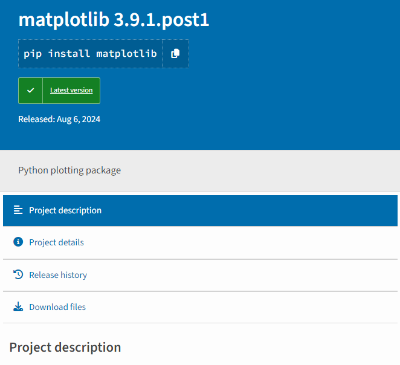

Nos arroja un poco de documentación de la librería, el comando es la instrucción que tenemos que correr en nuestra terminal para poder utilizarlo.

Aquí podremos encontrar los paquetes necesarios para poder utilizar en nuestros proyectos.

Para poder instalar algún paquete, correremos las siguientes lineas de comando en la terminal:

```
pip3 -V
pip3 install matplotlib
```

A continuación se nos va a descargar la librería y en esa librería puede que existan otras, como por ejemplo numpy, pillow, entre otras.

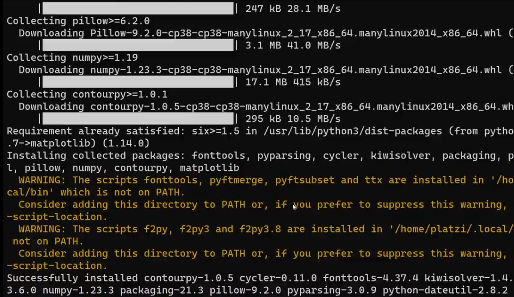

Procedemos a crear una carpeta llamada charts

Para ver que librerías están instaladas en nuestro ecosistema, ejecutamos el siguiente comando:

```
pip3 freeze
```

[figure not shown]

Aquí vemos la lista con los nombres de las librerías que tenemos instaladas de forma global, no por proyecto sino en toda la computadora.

## Creación de charts

Estando en la carpeta charts, crearemos 2 archivos:

- main.py
- charts.py

En charts.py utilizaremos la biblioteca *matplotlib*, incluyendo en el archivo el siguiente código:

```
import matplotlib.pyplot as plt

def generate_pie_chart():
    labels = ['A','B','C']
    values = [200,34,120]

    fig, ax= plt.subplots()
    ax.plt(values,labels=labels)
    plt.show()
```

pero vamos a cambiar `plt.show()` por `plt.savefig('pie.png')` quedando de la siguiente manera:

```
import matplotlib.pyplot as plt

def generate_pie_chart():
    labels = ['A','B','C']
    values = [200,34,120]

    fig, ax= plt.subplots()
    ax.plt(values,labels=labels)
    plt.savefig('pie.png')
    plt.close()
```

Luego vamos a ir al archivo main.py y generar el código:

```
import charts

def run():
    # Create a new chart
    charts.generate_pie_chart
```

Para que el código funcione como un script o modulo independiente, añadimos el siguiente bloque de código al final del archivo:

```
if __name__=='__main__':
    run()
```

Ahora hay que ejecutarlo dentro de la terminal, para eso nos posicionamos en la carpeta y corremos los siguientes códigos:

```
#Verificar donde estoy ubicado
pwd #debemos estar ubicados un nivel antes de py-project
cd py-project/charts

#Correr el archivo
python3 main.py
```

Si la abrimos obtendremos lo siguiente:

[figure not shown]